# Calculate functional diversity metrics

Casey O’Hara

7/25/2021

# Summary

Using functional entities defined in a prior script based on a suite of categorical traits, in combination with spatial distribution of species from AquaMaps, calculate functional diversity metrics based on Mouillot et al (2014) and code from Sebastien Villeger: functional richness, functional vulnerability, functional redundancy, and functional over-redundancy.

# Methods

## Identify AquaMaps species included in Functional Entity calculations

```r
spp_fe <- read_csv(here('_output/func_entities/species_fe.csv')) %>%
  select(species) %>%
  mutate(fe = TRUE) %>%
  distinct()
spp_am <- get_am_spp_info()  %>%
  select(species = sciname) %>%
  mutate(am = TRUE) %>%
  distinct()
spp_vuln <- get_spp_vuln() %>%
  select(species) %>%
  mutate(vuln = TRUE) %>%
  distinct()
spp_worms <- assemble_worms() %>%
  select(species) %>%
  mutate(worms = TRUE) %>%
  distinct()

all_spp <- spp_worms %>%
  full_join(spp_vuln, by = 'species') %>%
  full_join(spp_am,   by = 'species') %>%
  full_join(spp_fe,   by = 'species')

worms_mismatch <- all_spp %>% filter(is.na(worms))

### all AquaMaps spp
am_check <- get_am_spp_info() %>%
  filter(sciname %in% worms_mismatch$species)
table(am_check %>% select(kingdom, phylum))
```

```
##            phylum
## kingdom     annelida arthropoda bacillariophyta brachiopoda bryozoa chlorophyta
##   animalia         2         31               0           1       2           0
##   bacteria         0          0               0           0       0           0
##   chromista        0          0               0           0       0           0
##   plantae          0          0               2           0       0          96
##   protozoa         0          0               0           0       0           0
##            phylum
## kingdom     chordata ciliophora cyanobacteria dinophyta echinodermata
##   animalia         2          0             0         0             3
##   bacteria         0          0             8         0             0
##   chromista        0          0             0         0             0
##   plantae          0          0             0         0             0
##   protozoa         0          1             0         4             0
##            phylum
## kingdom     foraminifera granuloreticulosa kamptozoa magnoliophyta mollusca
##   animalia             0                 0        22             0      105
##   bacteria             0                 0         0             0        0
##   chromista            0                 0         0             0        0
##   plantae              0                 0         0             1        0
##   protozoa            81                 1         0             0        0
##            phylum
## kingdom     ochrophyta porifera rhodophyta sagenista tracheophyta
##   animalia           0        1          0         0            0
##   bacteria           0        0          0         0            0
##   chromista         64        0          0         2            0
##   plantae            0        0        116         0            9
##   protozoa           0        0          0         0            0
```

```r
table(am_check %>% filter(kingdom == 'animalia') %>% select(class, kingdom))
```

```
##                 kingdom
## class            animalia
##   actinopterygii        1
##   aplacophora           5
##   articulata            1
##   bivalvia             67
##   calcarea              1
##   echinoidea            1
##   gastropoda           31
##   gymnolaemata          2
##   holothuroidea         2
##   malacostraca         28
##   maxillopoda           3
##   not assigned         22
##   polychaeta            2
##   polyplacophora        1
##   reptilia              1
##   scaphopoda            1
```

## Load data

```r
fe_metrics_file <- here('_output/func_entities', 'fe_metrics.csv')
# unlink(fe_metrics_file)
if(!file.exists(fe_metrics_file)) {
  spp_fe <- read_csv(here('_output/func_entities/species_fe.csv'))
  am_spp_cells <- get_am_spp_cells()
  am_spp_info  <- get_am_spp_info() %>%
    select(-species, species = sciname) %>%
    filter(kingdom == 'animalia')
}
```

Then filter the species-cell lookup to just those species, for better performance.

```r
if(!file.exists(fe_metrics_file)) {
  am_spp_fe <- inner_join(am_spp_info, spp_fe, by = c('species')) %>%
    select(am_sid, species, occur_cells, iucn_sid, fe_code, fe_id, n_spp)
  am_cells_fe <- oharac::dt_join(am_spp_fe, am_spp_cells, by = 'am_sid', type = 'left') %>%
    select(loiczid, am_sid, fe_code, fe_id, prob)

  am_spp_nonfe <- am_spp_info %>%
    filter(!species %in% spp_fe$species)
  table(am_spp_nonfe$class)
  worms_spp <- assemble_worms()
  am_spp_nonworms <- am_spp_info %>%
    filter(!species %in% worms_spp$species)

  spp_fe_all <- spp_fe %>%
    left_join(worms_spp, by = 'species')
  mammals <- am_spp_info %>%
    filter(class == 'Mammalia') %>%
    full_join(spp_fe_all %>% filter(class == 'mammalia'),
              by = c('species' = 'species')) %>%
    select(am_sid, species, fe_id) %>%
    filter(is.na(am_sid) | is.na(fe_id))

}
```

## Calculate functional diversity metrics

This set of calculations replicates the results of Villeger’s function but without resorting to a presence/absence matrix, instead just relying on the original AquaMaps species-cell table.

- spp_fe_df joined to am_spp_cell;
- group by cell and functional group;
- calculate number of spp per functional group;
- group by cell;
- calculate functional entity metrics -
  - Species richness
  - Functional entity richness
  - Functional vulnerability (% of FEs represented by a single spp)
  - Weighted functional vulnerability (new: vuln of an FE is $\frac{1}{2^{n-1}}$, take average over all FE)
  - Functional redundancy (mean spp count per FE)
  - Functional over-redundancy (sum of spp per FE above mean, divided by total number of spp)

```r
if(!file.exists(fe_metrics_file)) {
  # system.time({

    am_cells_fe_thresh <- am_cells_fe %>%
      filter(prob >= .4) %>%
      select(-prob) %>%
      distinct()

    # system.time({
      nspp_df <- am_cells_fe_thresh %>%
        group_by(loiczid) %>%
        summarize(n_spp = n_distinct(am_sid),
                  n_fe  = n_distinct(fe_code),
                  .groups = 'drop')
    # }) ### 17 seconds

    ### this one is a bit slow:
    # system.time({
      nspp_fe_df <- am_cells_fe_thresh %>%
        group_by(loiczid, fe_code) %>%
        summarize(nspp_fe = n(), .groups = 'drop')
          ### using n() instead of n_distinct(); if no dupes
          ### in am_sid/loiczid/fe_code then should be fine.
    # }) ### 175 seconds

    # system.time({
      f_vuln_df <- nspp_fe_df %>%
        left_join(nspp_df, by = 'loiczid') %>%
        group_by(loiczid) %>%
        summarize(n_fe = first(n_fe), n_spp = first(n_spp),
                  f_vuln = sum(nspp_fe == 1) / n_fe,
                  f_wvuln = mean(0.5^(nspp_fe-1)),
                  f_red  = mean(nspp_fe),
                  .groups = 'drop')
      f_overred_df <- nspp_fe_df %>%
        left_join(f_vuln_df) %>%
        mutate(f_over = ifelse(nspp_fe > f_red, nspp_fe - f_red, 0)) %>%
        group_by(loiczid) %>%
        summarize(f_overred = sum(f_over) / sum(nspp_fe),
                  .groups = 'drop')
    # }) ### 7 sec

    fe_metrics_df <- f_vuln_df %>%
      full_join(f_overred_df, by = 'loiczid') %>%
      mutate(across(where(is.numeric), .fns = ~round(.x, 6)))
      ### rounding to 6 dec places saves a lot of storage for tifs
  # })
    # ggplot(fe_metrics_df, aes(x = f_vuln, y = f_wvuln)) +
    #   geom_point(alpha = .3) +
    #   geom_abline(slope = 1, intercept = 0)

  write_csv(fe_metrics_df, fe_metrics_file)
}
```

## Map functional diversity metrics

Create and save rasters of functional diversity metrics

```r
fe_metrics_df <- read_csv(fe_metrics_file)

n_spp_rast  <- map_to_hcaf(fe_metrics_df, which = 'n_spp')
n_fe_rast   <- map_to_hcaf(fe_metrics_df, which = 'n_fe')
f_vuln_rast <- map_to_hcaf(fe_metrics_df, which = 'f_vuln')
f_wvuln_rast <- map_to_hcaf(fe_metrics_df, which = 'f_wvuln')
f_red_rast  <- map_to_hcaf(fe_metrics_df, which = 'f_red')
f_overred_rast <- map_to_hcaf(fe_metrics_df, which = 'f_overred')

writeRaster(n_spp_rast,   here('_output/func_entities/n_spp.tif'),
            overwrite = TRUE)
writeRaster(n_fe_rast,    here('_output/func_entities/n_fe.tif'),
            overwrite = TRUE)
writeRaster(f_vuln_rast,  here('_output/func_entities/f_vuln.tif'),
            overwrite = TRUE)
writeRaster(f_wvuln_rast, here('_output/func_entities/f_wvuln.tif'),
            overwrite = TRUE)
writeRaster(f_red_rast,   here('_output/func_entities/f_red.tif'),
            overwrite = TRUE)
writeRaster(f_overred_rast, here('_output/func_entities/f_overred.tif'),
            overwrite = TRUE)
```

Examine distributions of each raster.

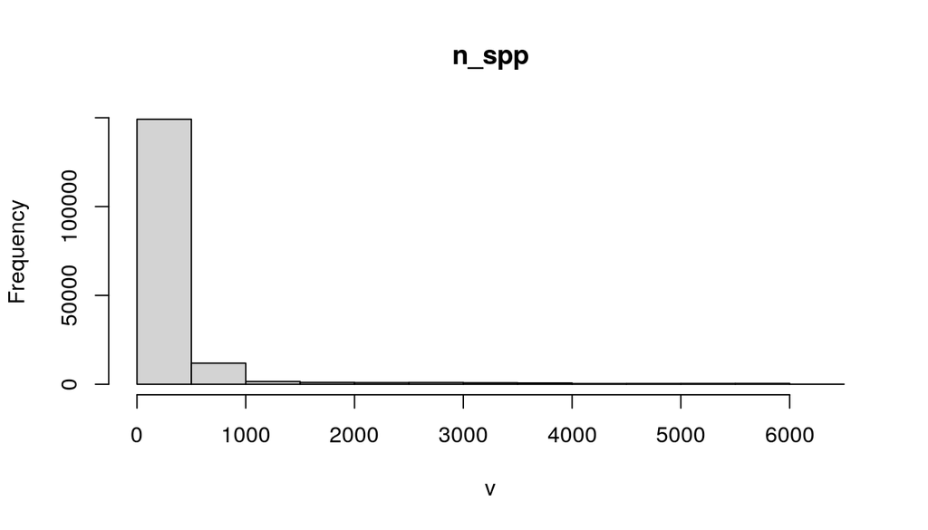

```r
hist(n_spp_rast)
```

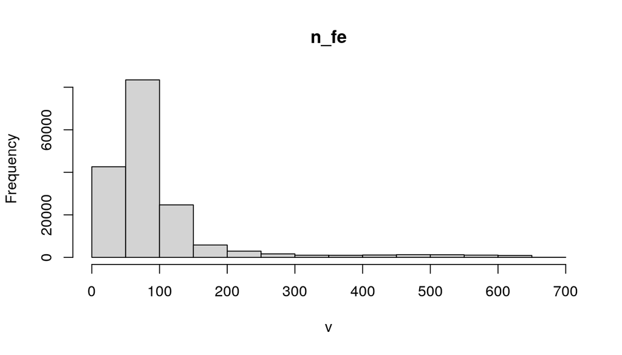

```r
hist(n_fe_rast)
```

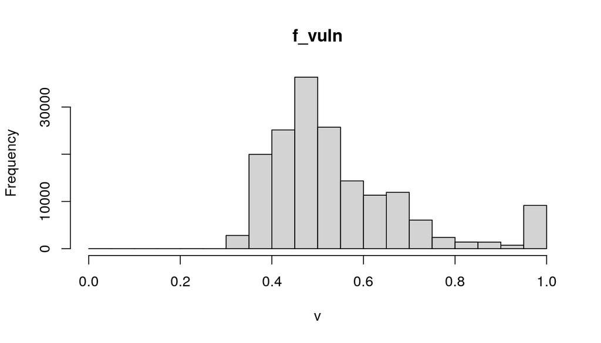

```r
hist(f_vuln_rast)
```

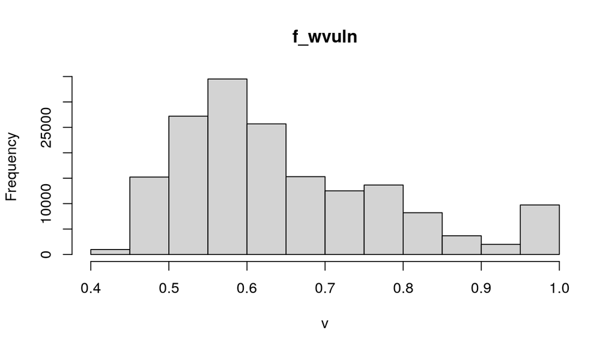

```r
hist(f_wvuln_rast)
```

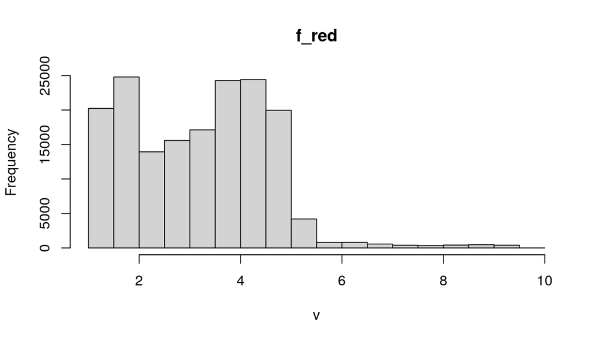

```r
hist(f_red_rast)
```

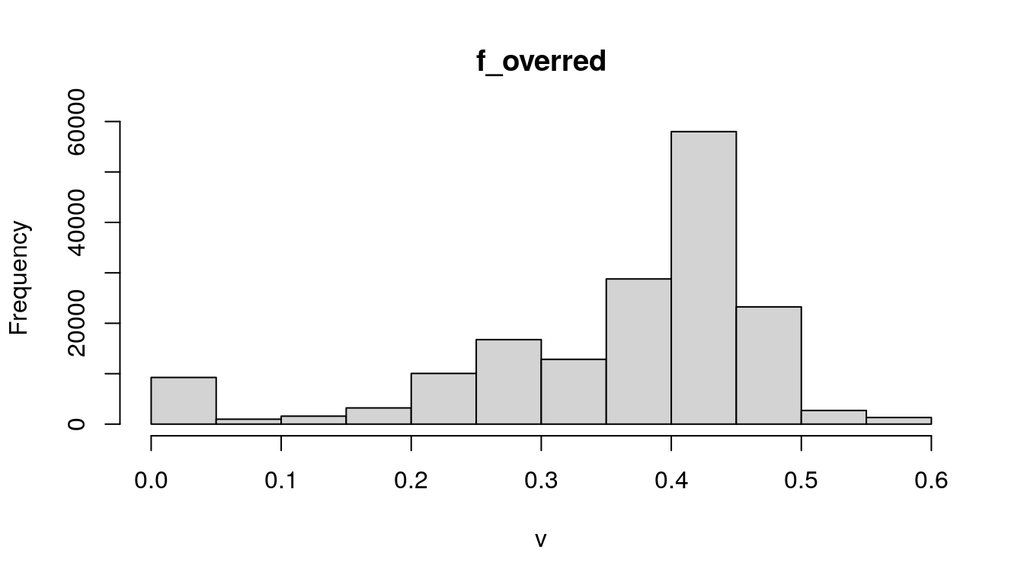

```r
hist(f_overred_rast)
```

Plot each raster.

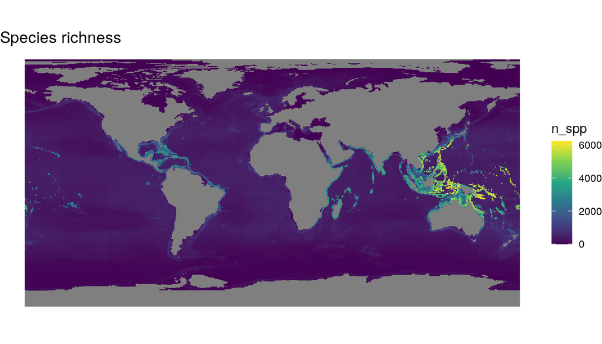

```r
plot_map <- function(r, main) {
  var_name <- sym(names(r))
  r_df <- as.data.frame(r, xy = TRUE)
  ### set fill scale limits based on raster values, from 0 to at least 1
  var_lim  <- c(min(0, minValue(r)), max(1, maxValue(r)))
  ggplot(r_df, aes(x, y, fill = !!var_name)) +
    geom_raster() +
    scale_fill_viridis_c(limits = var_lim) +
    coord_sf() +
    theme_void() +
    labs(title = main)
}
plot_map(n_spp_rast,   main = 'Species richness')
```

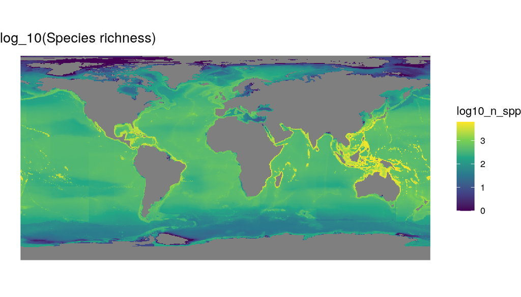

```r
plot_map(log10(n_spp_rast) %>% setNames('log10_n_spp'),  main = 'log_10(Species richness)')
```

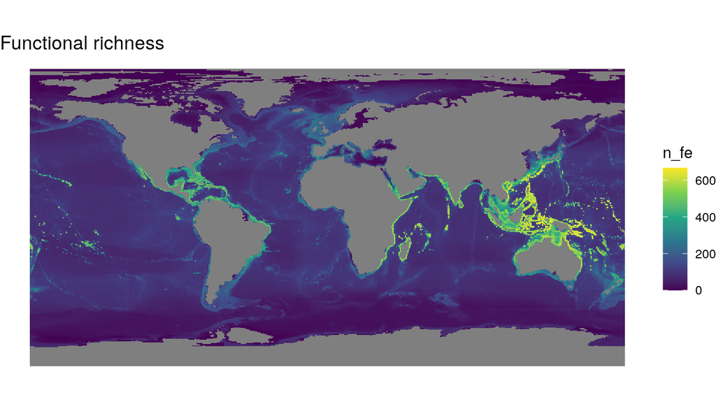

```r
plot_map(n_fe_rast,    main = 'Functional richness')
```

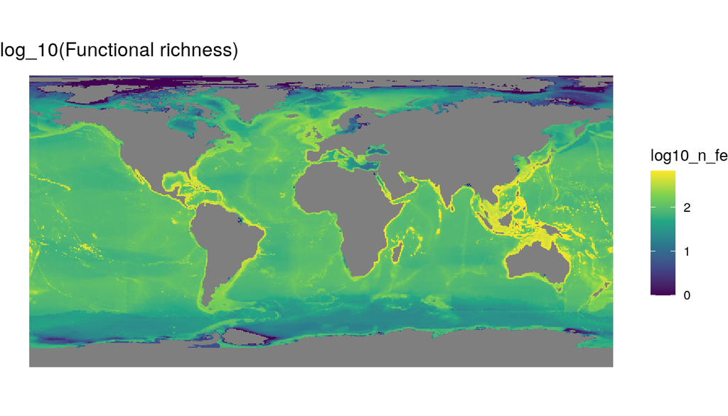

```r
plot_map(log10(n_fe_rast) %>% setNames('log10_n_fe'),  main = 'log_10(Functional richness)')
```

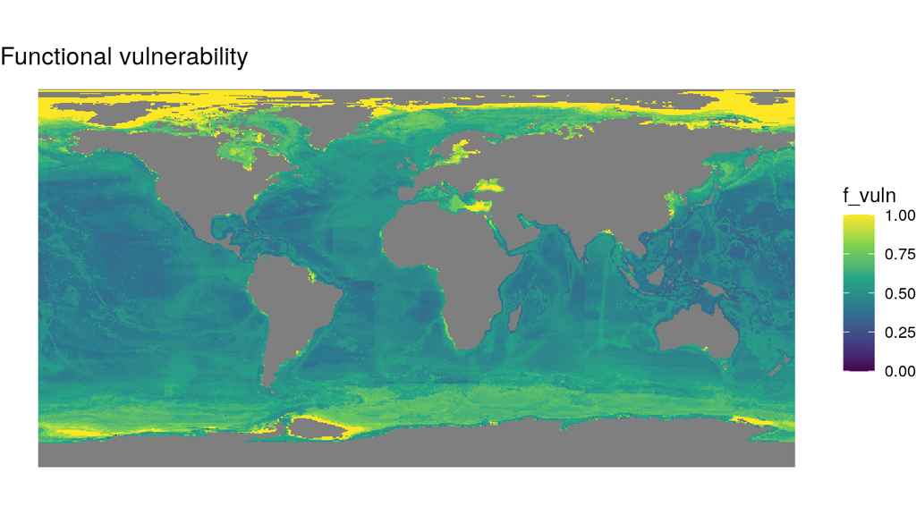

```r
plot_map(f_vuln_rast,  main = 'Functional vulnerability')
```

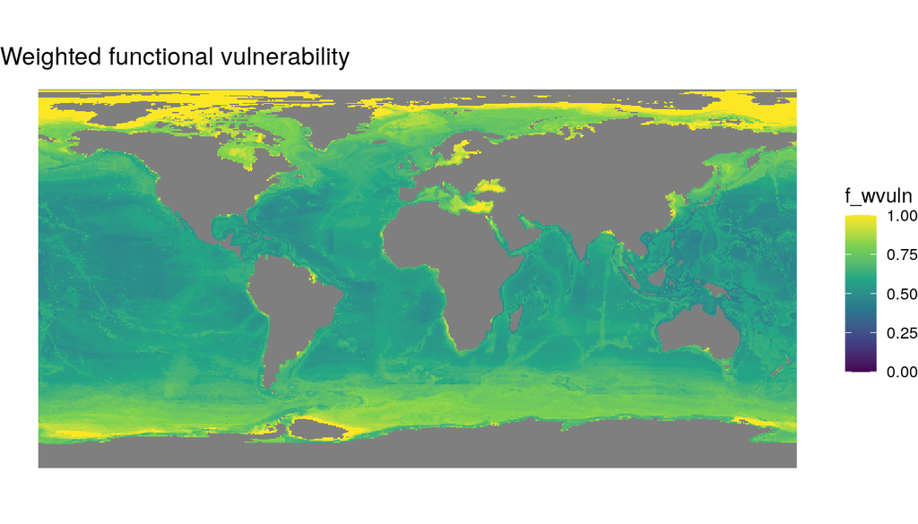

```r
plot_map(f_wvuln_rast, main = 'Weighted functional vulnerability')
```

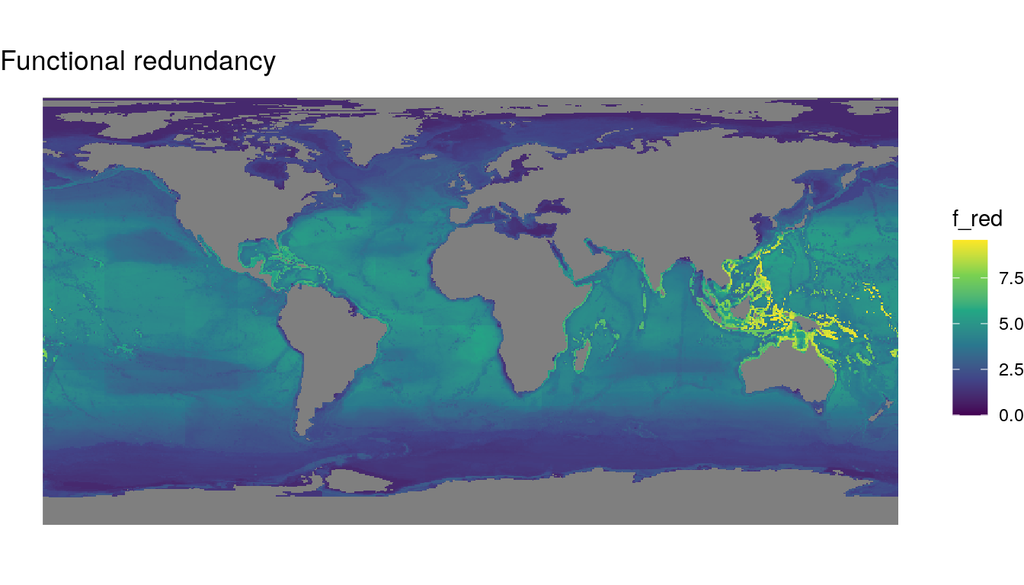

```r
plot_map(f_red_rast,   main = 'Functional redundancy')
```

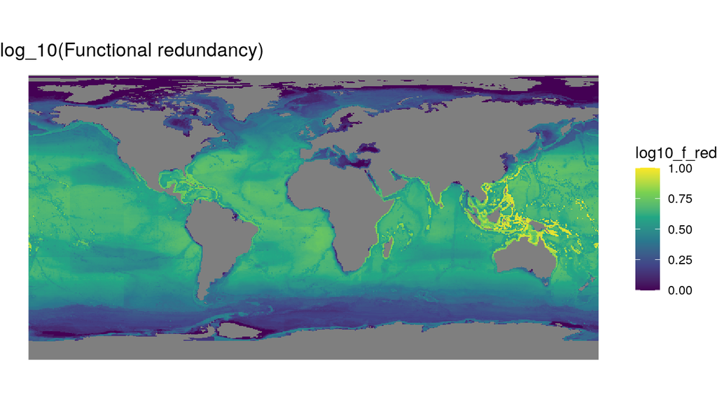

```r
plot_map(log10(f_red_rast) %>% setNames('log10_f_red'),  main = 'log_10(Functional redundancy)')
```

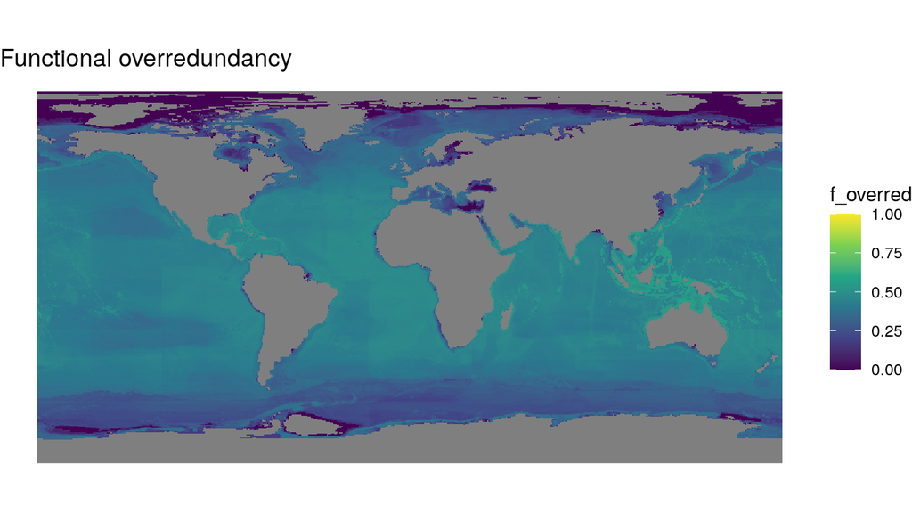

```r
plot_map(f_overred_rast, main = 'Functional overredundancy')
```